## Migration

Having now developed the basic analytical framework for quantifying population subdivision, we need to consider the process that prevents populations from being completely isolated from one another - migration, or gene flow. There are some fairly simple deterministic models that can be used to predict expected outcomes with respect to allele frequency changes; we will consider them briefly. However, bearing in mind that our real goal is to make inferences about how past migratory patterns have contributed to current distributions of genetic variation, it is worth is to explore migration in the context of coalescence in some detail.

### The Classical Approach

Here, we assume that we have two or more populations that consist of both natives and migrants; new migrants comprise a fraction m of each population in every generation. We can briefly consider a couple of scenarios

#### The Continent-island Model

In this case, we have a large population on an island, with some allele frequency p* , and a much smaller island population with allele frequency p, which receives a fraction of its population m from the continent every generation. We will assume that, because of the size difference between the two populations, migration from the island to the continent is effectively zero. What we wish to do is to calculate p’, the frequency on the island after one generation. The relationship is quite simple:

p’ = (1-m)p + mp*

Where the first term is the contribution of the native population (1-m) and the second is that of migrants (m). We can subtract p^* from both sides of the equation, thereby getting the difference between the island and mainland population on the left, and with a little bit of algebra we arrive at

p’-p* = (1-m)p + mp* -p<sup>2</sup> , and by rearranging the right side, we see that

p’-p* = (1-m)(p-p* )

and for t generations, we get

p<sup>t</sup> -p* = (1-m)<sup>t</sup> (p-p* )

or

p<sup>t</sup> = p* + (1-m)<sup>t</sup> (p-p*)

This, of course, we can visualize. We will examine the case where the allele we are following is initially fixed on the island population, has a frequency of 0.05 on the continent, and m=.01

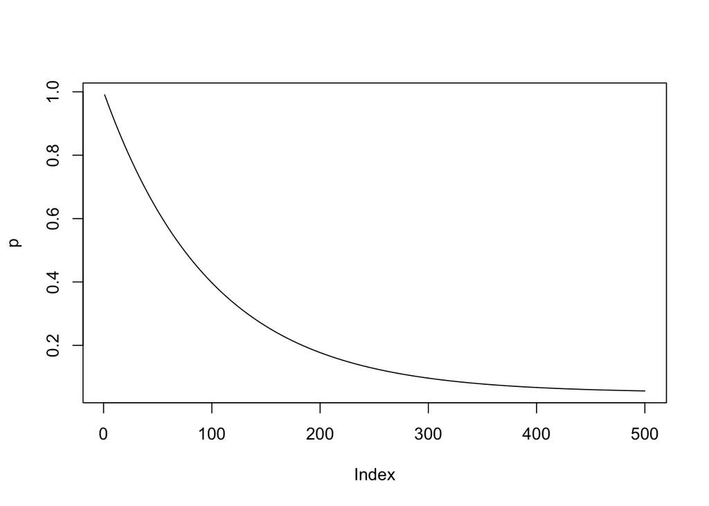

```r
pstar=.05
p0=1
m=.01
t <-c(1:500)
p <-pstar+(1-m)^t*(p0-pstar)
plot(p, type="l")
```

```r
p[500]
```

```
## [1] 0.05624196
```

```r
p[500]-pstar
```

```
## [1] 0.006241959
```

And perhaps not surprisingly, We see that the island allele frequency declines, such that by 500 generations it is 0.056242, which differs from the frequency on the continent by 0.006242.

#### The Island Model

Now consider a second scenario. Suppose we have 5 islands, each with some population N, and every generation there is a fraction m of the total population that migrates somewhere, randomly arriving at one of the five islands, including returning to its island of origin. Each island has some allele frequency p, and the average on all islands is pbar. By the same logic we used above, if we consider one island at time t

- p<sub>t</sub> = p <sub>t-1</sub>(1-m)+pbar*m

or for multiple generations

p <sub>t</sub> = pbar+(1-m)<sup>t</sup> *(p <sub>0</sub> - pbar)

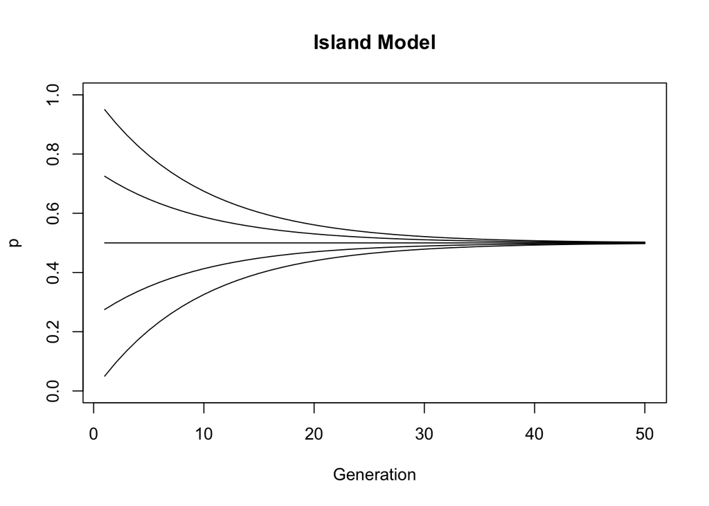

```r
# Below we initialize our variables and draw a blank plot
p <-c(0,.25,.5,.75,1)
m <-.1
t <- c(1:50)
pmean <-mean(p)
plot(t,xlim <-c(1:50), ylim=c(0,1), xlab="Generation", ylab="p", main="Island Model",type="n")
#  Now calculate the expected allele frequency changes and pltot them

traj <-lapply(p,function(x) pmean+(1-m)^t*(x-pmean))
lapply(traj,lines)
```

### Migration and Fst

There are other important models we need to consider - notably isolation by distance and divergence - but for now, from these verhy basic calculations we’ve done, it should be clear that migration is a strong force to reduce allele frequency differentiation among subpopulations. That suggests that we should be able to derive a relationship between migration rate and Fst. Remember that Fst is a measure of the reduction of heterozygosity resulting from allele frequency variation, and is thus a measure of the probability of identity by descent resulting from subdivision.

In that context, therefore, we can consider the following relationship:

- F <sub>t</sub> =(1/2N)(1-m)<sup>2</sup> +(1 - 1/2N)(1-m<sup>2</sup>) F <sub>t-1</sub>

This is the same recursion relationship we’ve used before (in the context of mutation, for example), only now we are weighting both the probability of ibd arising as the result of the fusion of identical gametes and that resulting from fusions of gametes that are ibd by virtue of previous generation by the probability that the individuals involved are not migrants. And, as we did previously, if we assume that N is large and m is small, we can drop terms containing m^2 or m/N, and when we do, we get the following at equilibrium:

Fst = 1/(1+4Nem)

Which looks exactly like what we saw for mutation. But there is something else that is worth noting. Remembering that m is the fraction of individuals that are migrant, and N is the total number of individuals, then **Nm is simply the number of migrants per generation**. So, with that in mind, we can now consider the relationship between Fst and number of migrants:

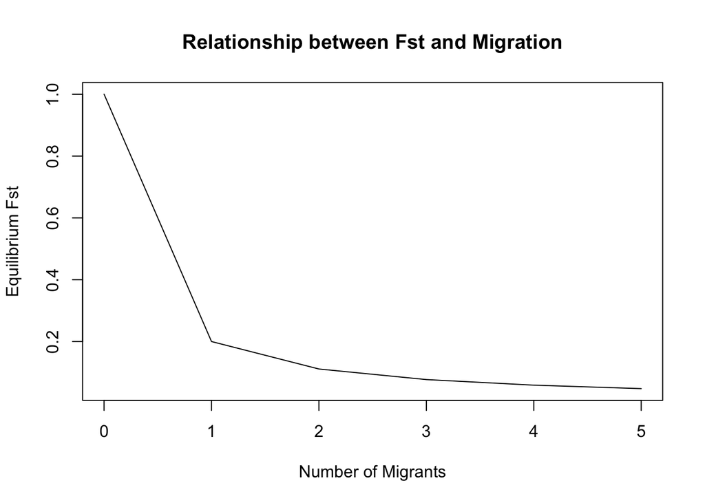

```r
M <-c(0:5)
fst <-1/(1+4*M)
plot(M,fst,xlab="Number of Migrants", ylab="Equilibrium Fst", main="Relationship between Fst and Migration",type="l")
```

```r
cbind(M,fst)
```

```
##      M        fst
## [1,] 0 1.00000000
## [2,] 1 0.20000000
## [3,] 2 0.11111111
## [4,] 3 0.07692308
## [5,] 4 0.05882353
## [6,] 5 0.04761905
```

What we see os that, using Wright’s benchmark of Fst < .05 as indicative of the lack of subdivision, it takes as few as 5 migrants per generation, **regardless of population size** to prevent the occurrence of detectable subdivision.

But having come up with a migration parameter that is comparable in form to θ, is rather obvious that our next step should to look at the process in the coalescent framework. This is where we are headed next.

### Migration and the Coalescent

#### A Simple Scenario

Suppose we are working with three populations, and we want to consider the histories of 10 alleles for our gene of interest from each. Nielsen and Slatkin develop the theory involved; we will touch on it occasionally. But let’s start with a simple truism. *If the populations have always been isolated, with no gene flow among them, then there is no MRCA*. So what we want to do to begin with is to look qualitatively at the effects of different migration rates, with those rates expressed in units of 4Nem.

We will start by using the -T option of ms to generate trees; in addition, we will introduce the -I (island) option. Its form in the ms command line (or in the opts= string in the phyclust function) is

-I n N1 N2 … Nn M

Where n is the number of subpopulations, Ni is the number of samples from the ith population, and M is the migration rate, where 1=4Nem.

We will start by writing a function that accepts a value of m as input and generates a single coalescent tree based on that value, as well as the other parameters of our scenario. We have arbitrarily set θ to be 3.

```r
migtree <-function(x) {
tr <-ms(nsam=30,nreps=1,opts=(paste("-t 3 -I 3 10 10 10", x,"-T",sep=" ")))
tr.ph <-read.tree(text=tr)
nms <-tr.ph$tip.label
nm2 <-as.numeric(sapply (nms, function (x) substr(x,2,nchar(x))))
nmcol=nm2

nmcol[which(nm2<=10)]="red"
nmcol[which(nm2>10&nm2<=20)]="green"
nmcol[which(nm2>20&nm2<=30)]="blue"
plot(tr.ph, tip.col=nmcol,main=paste("M =" ,x, sep=""))
}
```

Now, we will look at a few values of M

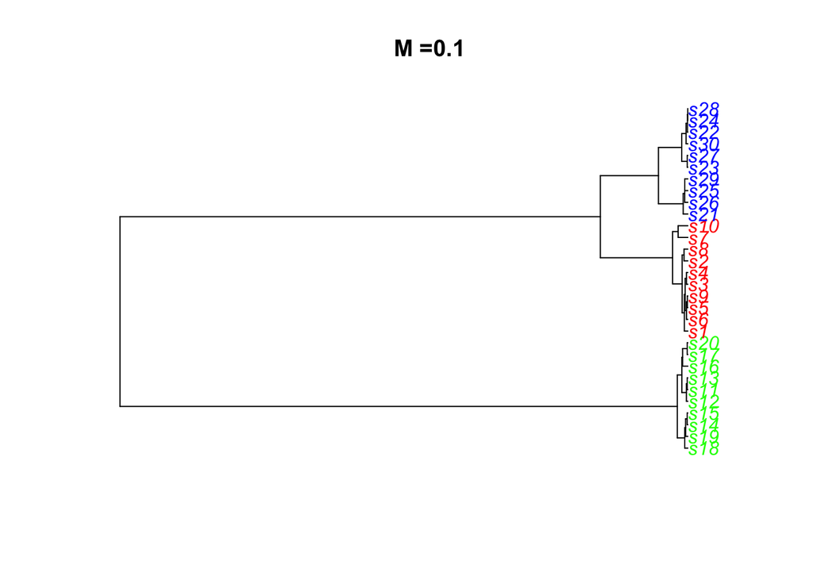

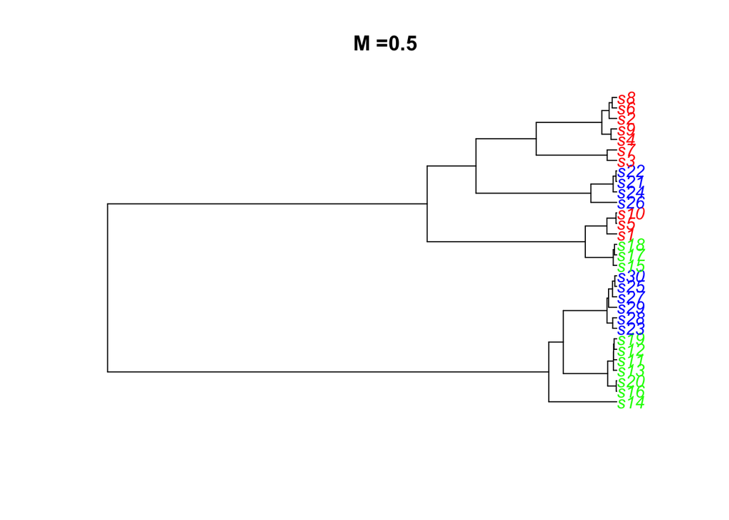

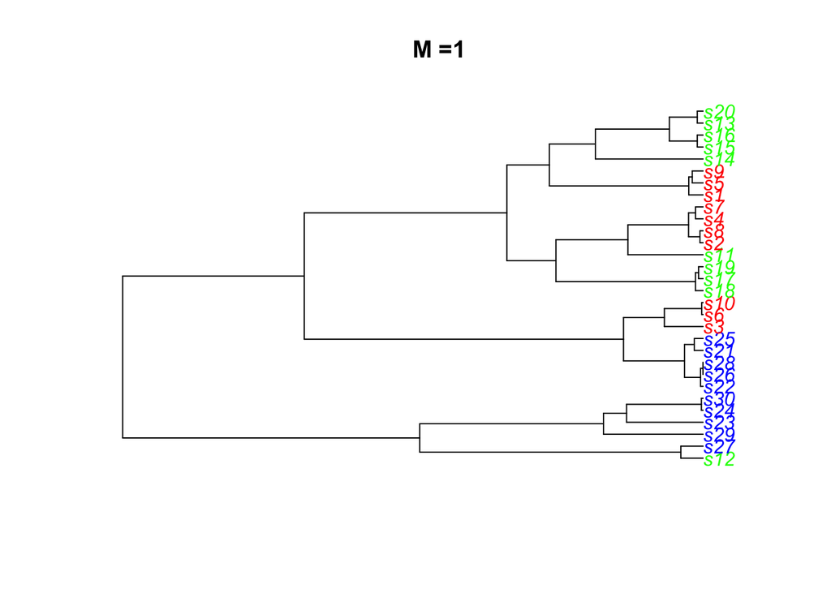

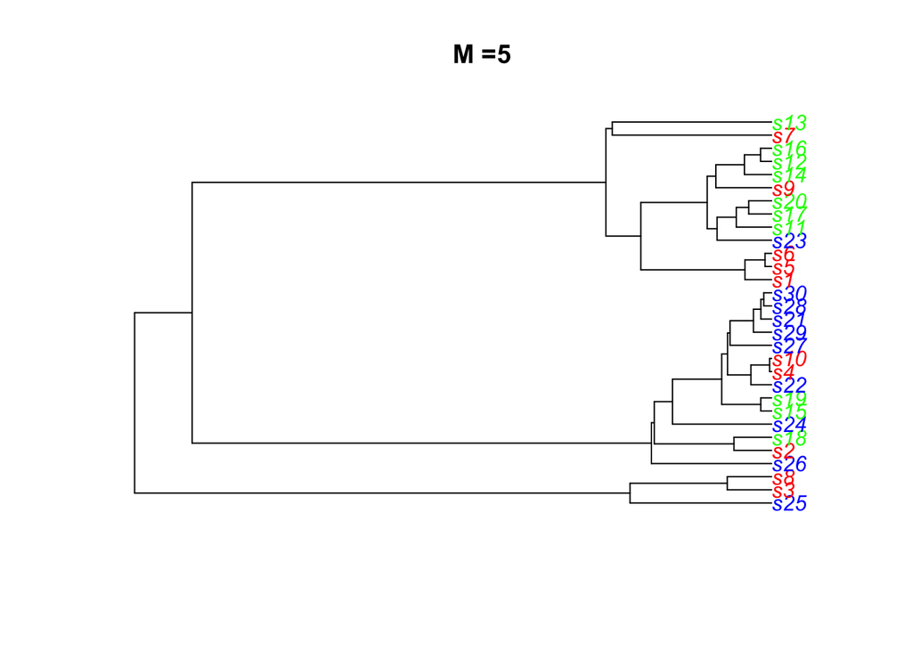

```r
set.seed(456)
#par(mfrow=c(2,2)) #create four panel display
M <-c(.1,.5,1,5)
sapply(M,migtree)
```

For visual effect, we’ve color-coded the samples from the three subpopulations. A few things are evident:

1. At low migration (e. g. M=.1) the three supopulations largely form separate clades. As M increases, this effect decreases, such that when M=5, there is no visually evident association between subpopulation and position on the geneology.
2. When migration rates are low, tip branches are typically short, which, based on what we’ve discussed previously, will results in higher values of π and thus higher values of D.

#### Summary statistics for the neutral coalescent with migration

We’ve already seen that we can use S and π as estimators of θ and that we can use the Tajima statistic as one means to test whether observed data fit the expectations of neutral coalescence. We have also shown, using classical analysis of heterozygosity, that we have a measure of subdivision, Fst, and that Fst is dependent on a θ -like parameter, 4Nem. It is a fairly simple process to demonstrate that in fact, the migration parameter functions very similarly to θ in affecting mean time to coalescence and so forth. But what we’d like to do now is to put these things together to explore the effect of migration in more detail.

```r
#system("msABC 30 1000 -t 3 -I 3 10 10 10 2 >msabc.migout")

sum.mig <-read.table("../msabc.migout",header=TRUE)
names(sum.mig)
```

```
##  [1] "s_segs_1"             "s_segs_2"             "s_segs_3"
##  [4] "s_segs"               "s_pi_1"               "s_pi_2"
##  [7] "s_pi_3"               "s_theta_pi"           "s_theta_w_1"
## [10] "s_theta_w_2"          "s_theta_w_3"          "s_theta_w"
## [13] "s_tajimasD_1"         "s_tajimasD_2"         "s_tajimasD_3"
## [16] "s_tajimasD"           "s_ZnS_1"              "s_ZnS_2"
## [19] "s_ZnS_3"              "s_ZnS"                "s_fst"
## [22] "s_perc_shared_1_2"    "s_perc_shared_1_3"    "s_perc_shared_2_3"
## [25] "s_perc_private_1_2"   "s_perc_private_1_3"   "s_perc_private_2_3"
## [28] "s_perc_fixed_dif_1_2" "s_perc_fixed_dif_1_3" "s_perc_fixed_dif_2_3"
## [31] "s_pairwise_fst_1_2"   "s_pairwise_fst_1_3"   "s_pairwise_fst_2_3"
## [34] "s_FayWuH_1"           "s_FayWuH_2"           "s_FayWuH_3"
## [37] "s_FayWuH"             "s_dvk_1"              "s_dvh_1"
## [40] "s_dvk_2"              "s_dvh_2"              "s_dvk_3"
## [43] "s_dvh_3"              "s_dvk"                "s_dvh"
## [46] "s_thomson_est_1"      "s_thomson_est_2"      "s_thomson_est_3"
## [49] "s_thomson_est"        "s_thomson_var_1"      "s_thomson_var_2"
## [52] "s_thomson_var_3"      "s_thomson_var"
```

And what we see is we get a whole bunch of data. Some of them (those whose name end with a number) are for the individual subpopulations; others are for the population as a whole. For now, we can concentrate on them, in particular the two we have alluded to before, Fst and D.

```r
par(mfrow=c(2,1))
fst.sim <-sum.mig$s_fst
colhist(fst.sim,xlab="Fst",,ylab="Number",main = "Fst - Migration")
mean(fst.sim)
```

```
## [1] 0.1735652
```

```r
d.sim <-sum.mig$s_tajimasD
mean(d.sim)
```

```
## [1] 0.08708557
```

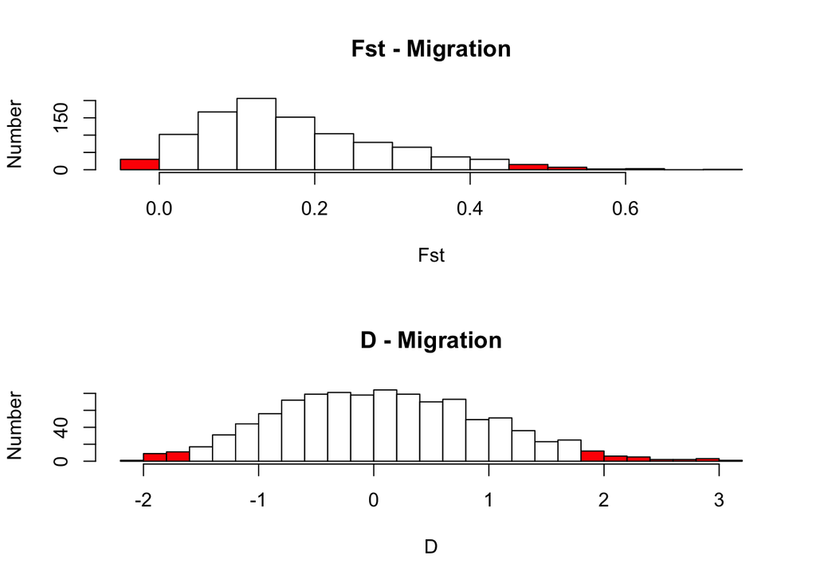

```r
colhist(d.sim, xlab="D",ylab= "Number",main="D - Migration")
```

So we see that Fst, based on the simulation approach, is significantly different from zero. D, while positive, is not.

### Another Scenario - Divergence

#### Overview

Up until now, we have considered a model of a subdivided population, in which migration is a constant over time (the island model). But what about the case in which subpopulations result from a vicariance event, in which a single population was, at some point in history, split into two?

So let’s look at two trees and see what we get

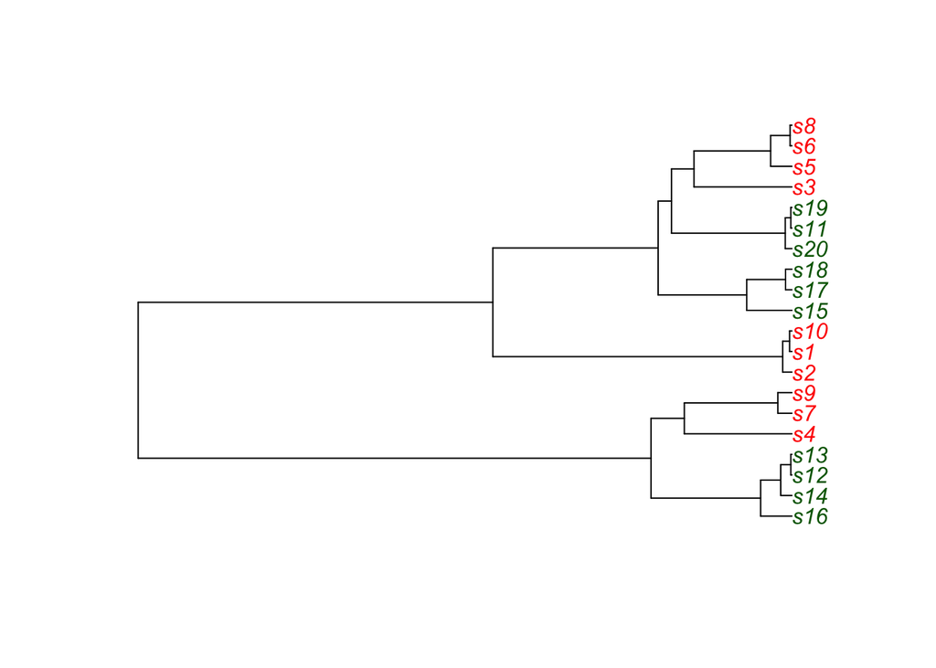

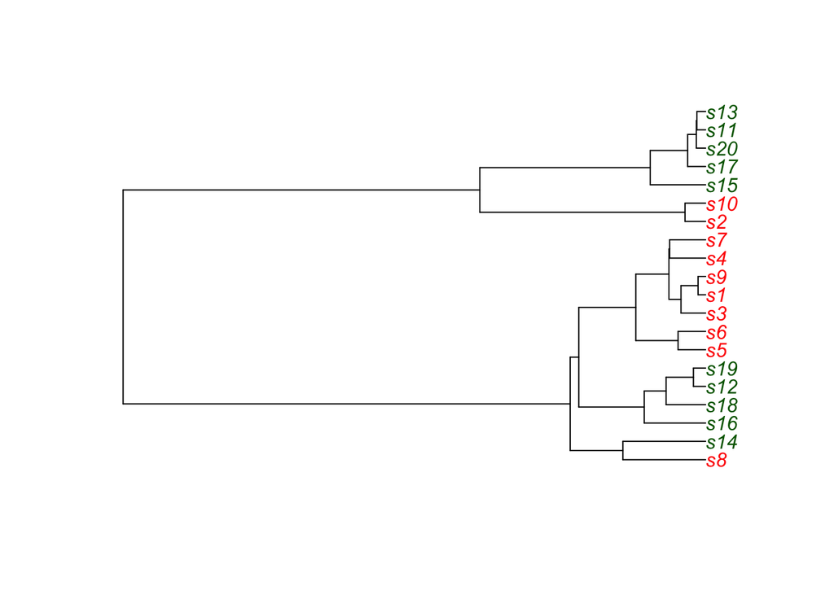

```r
set.seed(3234)
#par(mfrow=c(2,1))
for (i in 1:2) {
ms.div <-ms(nsam=20, nreps=1,opts=("-t 4 -I 2 10 10 -ej .18375 2 1 -T"))

tr.div <-read.tree(text=ms.div)
nms <-tr.div$tip.label
nm2 <-as.numeric(sapply (nms, function (x) substr(x,2,nchar(x))))
nmcol=nm2

nmcol[which(nm2<=10)]="red"
nmcol[which(nm2>10&nm2<=20)]="darkgreen"
plot(tr.div,tip.col=nmcol)
}
```

```r
#system("msABC 20 1000 -t 4 -I 2 10 10 -ej .1875 2 1 >msabc.div")
msabc.div <-read.table("../msabc.div",header=TRUE)
#names(msabc.div)
```

And we can look at what we see:

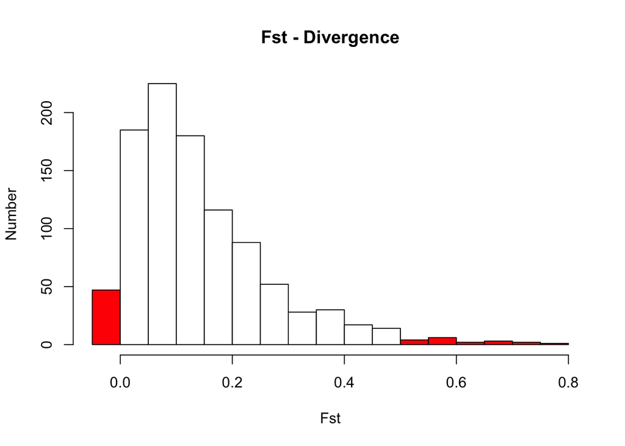

```r
colhist(msabc.div$s_fst,xlab="Fst",ylab="Number",main="Fst - Divergence")
```

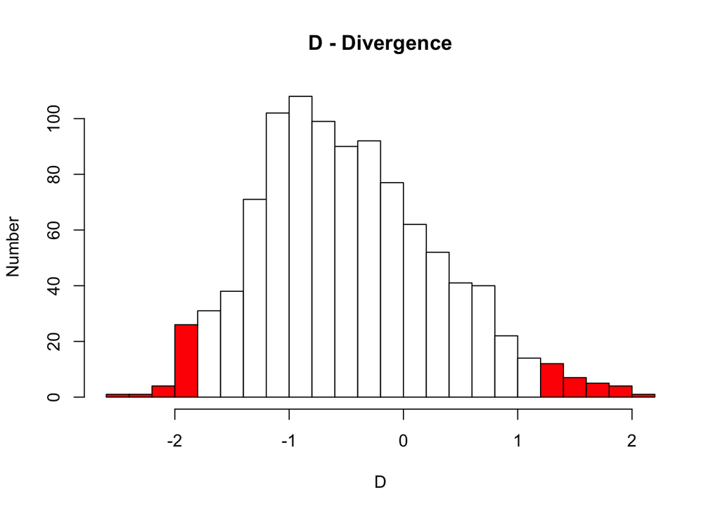

```r
colhist(msabc.div$s_tajimasD,xlab="D",ylab="Number",main="D - Divergence")
```

```r
mean(msabc.div$s_fst)
```

```
## [1] 0.1427414
```

```r
mean(msabc.div$s_tajimasD)
```

```
## [1] -0.4759347
```

So if we compare results from the two models, we can see that Fst does not distinguish between them. With respect to D, while the migration mean of the migration model is positive and that of the divergence one is negative, in fact neither value is significantly different from zero.

### Conclusions

We can wrap up our use of coalescent simulations up to now with a few broad statements:

1. The neutral coalescent provides us with an excellent way to model DNA sequence evolution in populations - we can compare observed data (π and S) to those expected under either simple (θ as the only parameter) or more complex models.
2. In the simple case of constant population size and mutation rate, with no subdivision, we can use Bayesian logic as a means of getting at least a rough estimate of the neutral parameter.
3. As we make the model more complex, adding demographics and/or population structure into the mix, our problems multiply.
4. Using the statistics we have focused on to date, we find ourselves unable to distinguish between two very distinct models of population history.

This last point is probably the most important. We have devised two very different biological scenarios - an island model with migration and an historical divergence one without, and what we see is that the expectations for a single-slice-in-time data sample are in fact minimally different. So in a real-world situation, perhaps one involving species conservation or habitat protection, our ability up to this point to provide practical input is limited.

But there is hope. If we can develop the means to explore the parameter space more fully - starting not just with a prior distribution of θ but also with ones for factors such as population growth rate, migration, etc., we might be able to refine our explanatory hypotheses. This is where we will be headed in the future.

## Isolation By Distance

Heretofore, we have not let geographic distance into the picture. In our island model, for example, we assumed equal rates of migration among all islands, regardless of location. A more realistic model, particularly for a series of continental populations, would involve migration rate as an inverse function of the distance between pairs of populations. The question we thus have is to accomplish this.

Rather than use the modeling approach we have previously, we will instead apply a model developed by [Rousset (1997)](http://www.genetics.org/content/145/4/1219.short) to some original data. What he showed was that, if we consider distance to be one dimension, then in fact, Fst(1-Fst) would be expected to be a linear function of geographic distance. More sophisticated models could be developed for three dimensions, but they go beyond what we need to consider

### Some data

[Jensen et al (2013)](http://onlinelibrary.wiley.com/doi/10.1111/mec.12226/full) reported a survey of microsatellite variation in sparrows along the Atlantic coast of Norway. 14 populations were genotyped at 15 microsatellite loci. The locations are shown here:

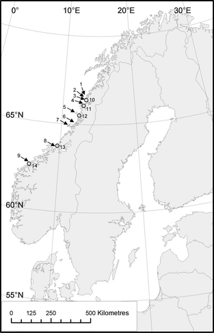

Sparrows in Norway

The genotype data were deposited in Dryad; in addition, spatial coordinates of the population sites were reported in the paper. I have used Genalex to calculate pairwise Fst values; in addition, the coordinates were converted to distances (km), and both data sets were saved as triangular matrices. We will read both of them in and convert them to vectors, in order that we can plot the Rousset relationship

Load the distance matrices:

```r
data(Sparrow)
attach(sparrow.dat)
dist.km.vec <-dist.km[!is.na(dist.km)]
dist.km.vec
```

```
##  [1]  12  25  52 118 181 211 369 530  19  60 126 360 543  20  42 107 171
## [18] 200 358 519  15  51 116 348 532  31  98 160 192 350 514   6  36 104
## [35] 340 526  67 130 161 319 483  36  14  74 309 496  65  94 252 418 102
## [52]  66  20 242 430  37 192 363 165 126  57 181 374 158 327 196 159  91
## [69] 148 338 179 355 317 249  13 187 518 484 418 192  19  41 109 345 530
## [86]  69 306 495 238 429 199
```

And then the Fst one

```r
dist.fst.vec <-dist.fst[!is.na(dist.fst)]
dist.fst.vec
```

```
##  [1] 0.0155 0.0723 0.0253 0.0293 0.0280 0.0255 0.0308 0.0338 0.0150 0.0227
## [11] 0.0266 0.0225 0.0352 0.0621 0.0204 0.0242 0.0230 0.0160 0.0219 0.0222
## [21] 0.0119 0.0165 0.0210 0.0221 0.0265 0.0707 0.0687 0.0741 0.0729 0.0691
## [31] 0.0706 0.0536 0.0651 0.0646 0.0679 0.0770 0.0219 0.0206 0.0191 0.0356
## [41] 0.0307 0.0168 0.0166 0.0162 0.0236 0.0323 0.0245 0.0175 0.0438 0.0277
## [51] 0.0292 0.0223 0.0228 0.0256 0.0271 0.0105 0.0343 0.0186 0.0190 0.0132
## [61] 0.0123 0.0127 0.0223 0.0254 0.0177 0.0203 0.0107 0.0151 0.0120 0.0131
## [71] 0.0260 0.0239 0.0334 0.0303 0.0175 0.0228 0.0274 0.0234 0.0245 0.0106
## [81] 0.0059 0.0104 0.0119 0.0200 0.0329 0.0096 0.0179 0.0291 0.0167 0.0297
## [91] 0.0084
```

Now we will calculate Fst/1-Fst and plot it against distance. We will then calculate the regression line and add it to the plot

```r
Fsthat <-dist.fst.vec/(1-dist.fst.vec)

plot(dist.km.vec,Fsthat, xlab="Distance(km)", ylab="Fst/(1-Fst)", pch=16)

reg <-lm(Fsthat~(dist.km.vec))
summary(reg)
```

```
##
## Call:
## lm(formula = Fsthat ~ (dist.km.vec))
##
## Residuals:
##       Min        1Q    Median        3Q       Max
## -0.020854 -0.011018 -0.005968 -0.000258  0.051416
##
## Coefficients:
##              Estimate Std. Error t value Pr(>|t|)
## (Intercept) 2.612e-02  3.383e-03   7.720 1.62e-11 ***
## dist.km.vec 1.613e-05  1.238e-05   1.303    0.196
## ---
## Signif. codes:  0 '***' 0.001 '**' 0.01 '*' 0.05 '.' 0.1 ' ' 1
##
## Residual standard error: 0.01949 on 89 degrees of freedom
## Multiple R-squared:  0.01872,    Adjusted R-squared:  0.007696
## F-statistic: 1.698 on 1 and 89 DF,  p-value: 0.1959
```

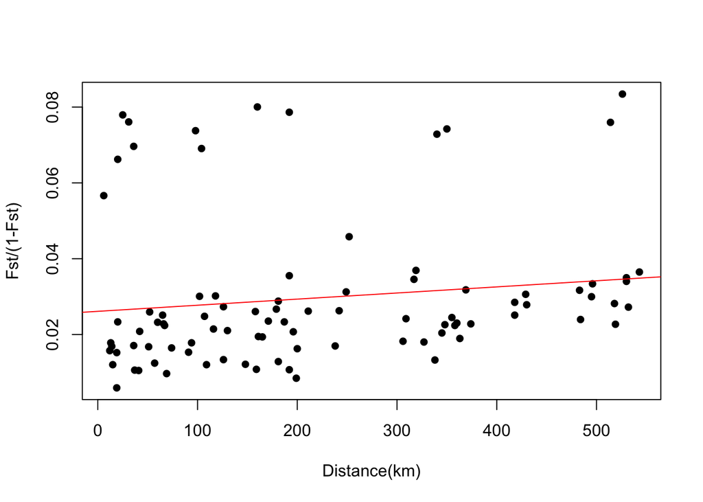

```r
abline(reg,col="red")
```

Note that there is trend, but it is not significant. we also see that there is a collection of outliers that do not appear to be consistent with the rest. we can see this more clearly if we make a histogram of the pairwise Fst values:

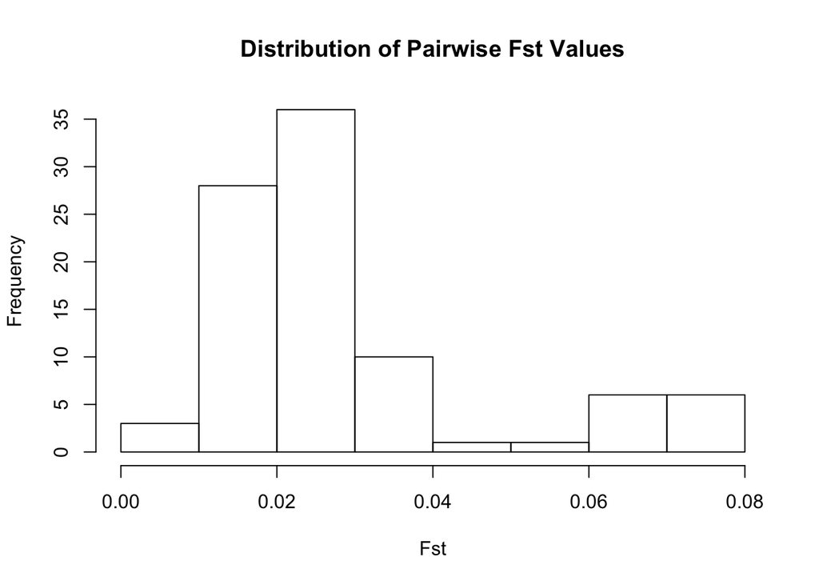

```r
hist(dist.fst.vec, main="Distribution of Pairwise Fst Values", xlab="Fst")
```

In fact, Jensen et al. explain this in their paper by noting that in fact the populations sampled included ones from both the islands and the mainland. When they performed the same analysis with mainland-mainland, mainland-island, or island-island comparisons, they observed the following:

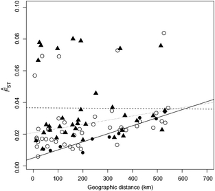

Data

The strongest relationship was observed in the mainland-mainland comparisons (filled circles; solid line); Fst values in general were higher for island-island comparisons. From these results, the concluded the following:

1. Within population variation on islands is overall lower than on the mainland, while pairwise Fst values tended to be higher, suggesting repeated independent bottlenecks and/or founder effects on the islands.
2. In contrast, the lower differentiation among mainland populations and patterns of Fst suggest a larger overall population, with differentiation mediated by weak isolation-by-distance population structuring.

### Another approach - Mantel’s test

Think for a moment about what we have - two matrices, one of genetic differences and one of geographic ones. If indeed isolation by distance exists, then we would expect the two matrices to be correlated, right? But a simple correlation coefficient will not suffice, since the elements of the matrix are not independent of one another. If for example, site one is moved, then its distance to all other n-1 sites is also changed. Thus, we need another method.

The Mantel Test is one of those, and involves a randomization process similar to what we have done in other cases. The process is conceptually simple:

1. Calculate the correlation between the two matrices
2. Randomize the rows and columns of one of the two (usually the genetic distance matrix)
3. Calculate the correlation between the fixed and randomized values
4. Repeat, and look at the distributions

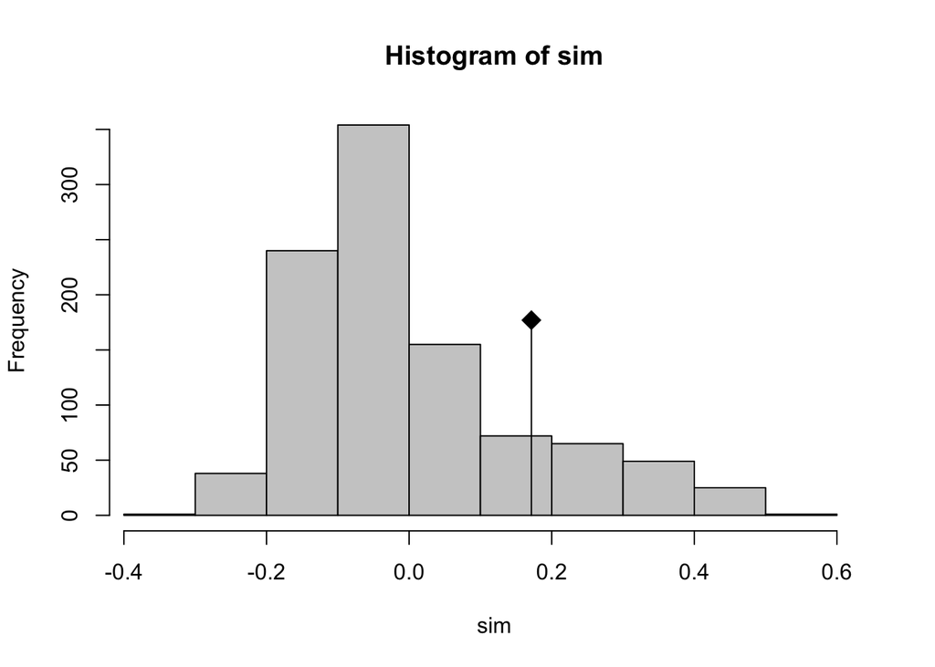

```r
m <-mantel.rtest(as.dist(sparrow.dat$dist.km),as.dist(sparrow.dat$dist.fst),nrepet=1000)
plot(m)
```

```r
m
```

```
## Monte-Carlo test
## Observation: 0.1714625
## Call: mantelnoneuclid(m1 = m1, m2 = m2, nrepet = nrepet)
## Based on 1000 replicates
## Simulated p-value: 0.1618382
```

### Conclusions

What we have done here is a very preliminary analysis; in real life we would have coded the data in such a way that we could, perhaps, look at nested F statistics or broken them out as shown above. But this is an excellent example of how, combining theory, geography, and genetic data, we can obtain real insights into population differentiation.